# Pertemuan 5

Nadila Putri Fauziyyah

2023-09-26

```r
library(ggplot2)
library(tsibble)
library(tseries)
library(MASS)
```

# Memeriksa Kestasioneran Data

## Input Data

```r
data1 <- rio::import("https://raw.githubusercontent.com/nadilaputrif/MPDW-NadilaPF/main/Data/Data_suhu.csv")
data1
```

```
##     Periode  Suhu
## 1         1 23.71
## 2         2 24.76
## 3         3 24.73
## 4         4 24.76
## 5         5 25.03
## 6         6 24.08
## 7         7 23.79
## 8         8 23.91
## 9         9 23.91
## 10       10 23.58
## 11       11 24.02
## 12       12 23.20
## 13       13 24.12
## 14       14 22.95
```

[output cut: 142 more lines]

## Eksplorasi Data (Plot Time Series)

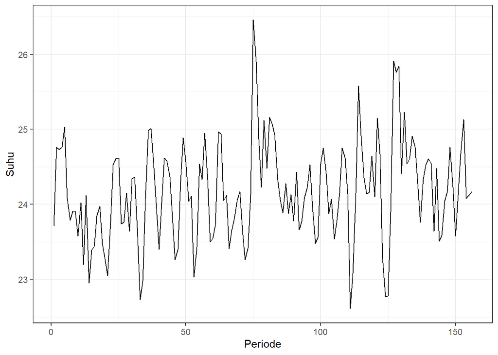

```r
Periode <- data1$Periode
Suhu <- data1$Suhu
data1.ts <-ts(data1$Suhu)

plot_stas <- data1.ts |> as_tsibble() |>
  ggplot(aes(x = Periode, y = Suhu)) + geom_line() + theme_bw() +
  xlab("Periode") + ylab("Suhu")
plot_stas
```

```r
mean(data1.ts)
```

```
## [1] 24.16981
```

Plot deret waktu di atas menunjukkan bahwa data stasioner dalam rataan, ditandai dengan data yang menyebar di sekitar nilai tengahnya (24) dan stasioner dalam ragam, ditandai dengan lebar pita yang cenderung sama.

## Plot ACF

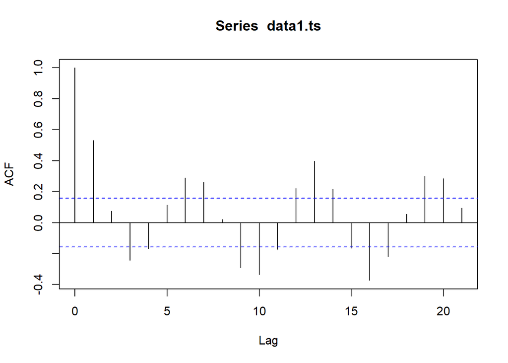

```r
acf(data1.ts)
```

Berdasarkan plot ACF, terlihat bahwa plot ACF pada data tersebut cenderung *tails off* dan membentuk gelombang sinus.

## Uji ADF

```r
tseries::adf.test(data1.ts)
```

```
##
##  Augmented Dickey-Fuller Test
##
## data:  data1.ts
## Dickey-Fuller = -4.332, Lag order = 5, p-value = 0.01
## alternative hypothesis: stationary
```

$H_0$ : Data tidak stasioner dalam rataan

$H_1$ : Data stasioner dalam rataan

Berdasarkan uji ADF tersebut, didapat p-value sebesar 0.01 yang lebih kecil dari taraf nyata 5% sehingga tolak $H_0$ dan menandakan bahwa data **stasioner dalam rataan**. Hal ini sesuai dengan hasil eksplorasi menggunakan plot time series dan plot ACF.

## Plot Box-Cox

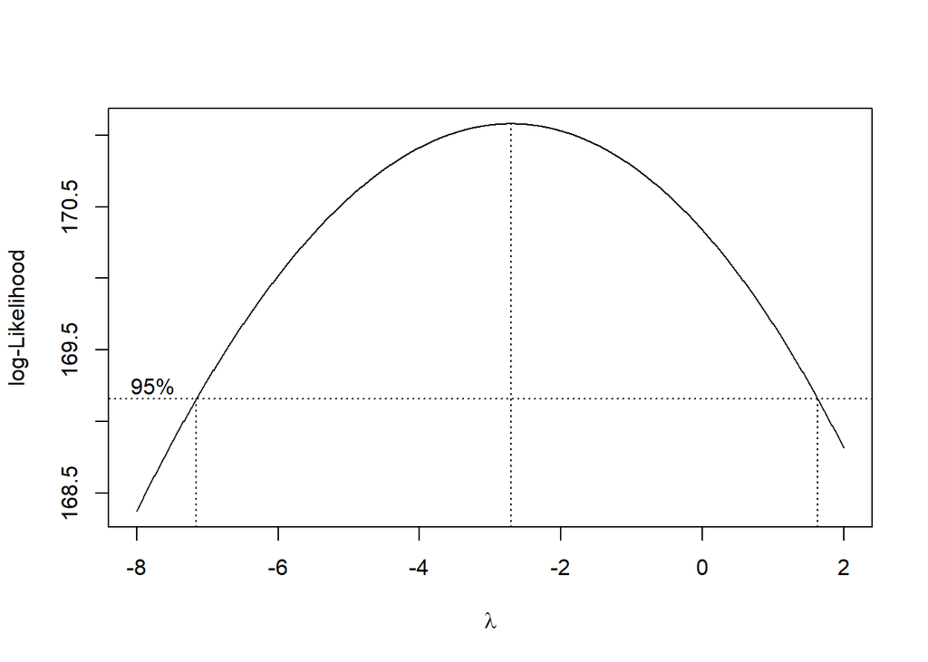

```r
index <- seq(1:156)
bc = boxcox(data1.ts~index, lambda = seq(-8,2,by=0.01))
```

```r
#Nilai Rounded Lambda
lambda <- bc$x[which.max(bc$y)]
lambda
```

```
## [1] -2.71
```

```r
#SK
bc$x[bc$y > max(bc$y) - 1/2 * qchisq(.95,1)]
```

```
##   [1] -7.15 -7.14 -7.13 -7.12 -7.11 -7.10 -7.09 -7.08 -7.07 -7.06 -7.05 -7.04
##  [13] -7.03 -7.02 -7.01 -7.00 -6.99 -6.98 -6.97 -6.96 -6.95 -6.94 -6.93 -6.92
##  [25] -6.91 -6.90 -6.89 -6.88 -6.87 -6.86 -6.85 -6.84 -6.83 -6.82 -6.81 -6.80
##  [37] -6.79 -6.78 -6.77 -6.76 -6.75 -6.74 -6.73 -6.72 -6.71 -6.70 -6.69 -6.68
##  [49] -6.67 -6.66 -6.65 -6.64 -6.63 -6.62 -6.61 -6.60 -6.59 -6.58 -6.57 -6.56
##  [61] -6.55 -6.54 -6.53 -6.52 -6.51 -6.50 -6.49 -6.48 -6.47 -6.46 -6.45 -6.44
##  [73] -6.43 -6.42 -6.41 -6.40 -6.39 -6.38 -6.37 -6.36 -6.35 -6.34 -6.33 -6.32
##  [85] -6.31 -6.30 -6.29 -6.28 -6.27 -6.26 -6.25 -6.24 -6.23 -6.22 -6.21 -6.20
##  [97] -6.19 -6.18 -6.17 -6.16 -6.15 -6.14 -6.13 -6.12 -6.11 -6.10 -6.09 -6.08
## [109] -6.07 -6.06 -6.05 -6.04 -6.03 -6.02 -6.01 -6.00 -5.99 -5.98 -5.97 -5.96
## [121] -5.95 -5.94 -5.93 -5.92 -5.91 -5.90 -5.89 -5.88 -5.87 -5.86 -5.85 -5.84
## [133] -5.83 -5.82 -5.81 -5.80 -5.79 -5.78 -5.77 -5.76 -5.75 -5.74 -5.73 -5.72
## [145] -5.71 -5.70 -5.69 -5.68 -5.67 -5.66 -5.65 -5.64 -5.63 -5.62 -5.61 -5.60
## [157] -5.59 -5.58 -5.57 -5.56 -5.55 -5.54 -5.53 -5.52 -5.51 -5.50 -5.49 -5.48
## [169] -5.47 -5.46 -5.45 -5.44 -5.43 -5.42 -5.41 -5.40 -5.39 -5.38 -5.37 -5.36
```

[output cut: 59 more lines]

Gambar di atas menunjukkan nilai rounded value ($\lambda$) optimum sebesar -2.71 dan pada selang kepercayaan 95% nilai memiliki batas bawah -7.15 dan batas atas 1.63. Selang tersebut memuat nilai satu sehingga dapat dikatakan bahwa data suhu **stasioner dalam ragam**.

# Partisi

## Bagian 1 (data 1 - 52)

```r
dt_stas1 <- data1.ts[1:52] |> ts()
mean(dt_stas1)
```

```
## [1] 23.99865
```

```r
var(dt_stas1)
```

```
## [1] 0.3392236
```

## Plot *Time Series*

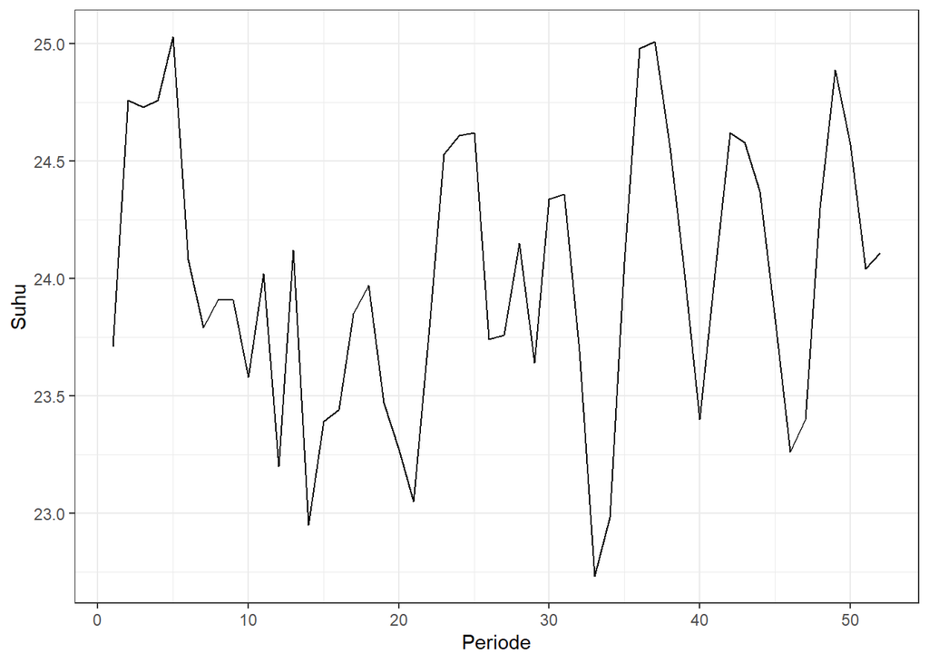

```r
dt_stas1 |> as_tsibble() |>
  ggplot(aes(x = index, y = value)) +
  geom_line() + theme_bw() +
  xlab("Periode") + ylab("Suhu")
```

Plot deret waktu di atas menunjukkan bahwa data stasioner dalam rataan, ditandai dengan data yang menyebar di sekitar nilai tengahnya (24) dan stasioner dalam ragam, ditandai dengan lebar pita yang cenderung sama.

## Plot ACF

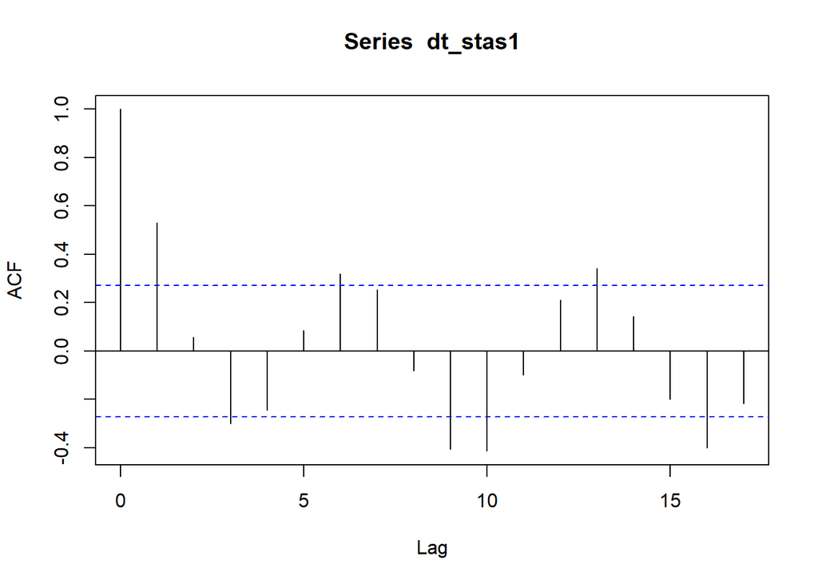

```r
acf(dt_stas1)
```

Berdasarkan plot ACF, terlihat bahwa plot ACF pada data tersebut cenderung *tails off* dan membentuk gelombang sinus.

## Uji ADF

```r
tseries::adf.test(dt_stas1)
```

```
##
##  Augmented Dickey-Fuller Test
##
## data:  dt_stas1
## Dickey-Fuller = -3.5652, Lag order = 3, p-value = 0.04448
## alternative hypothesis: stationary
```

$H_0$ : Data tidak stasioner dalam rataan

$H_1$ : Data stasioner dalam rataan

Berdasarkan uji ADF tersebut, didapat p-value sebesar 0.04448 yang lebih kecil dari taraf nyata 5% sehingga tolak $H_0$ dan menandakan bahwa data **stasioner dalam rataan**. Hal ini sesuai dengan hasil eksplorasi menggunakan plot time series dan plot ACF.

## Plot Boxcox

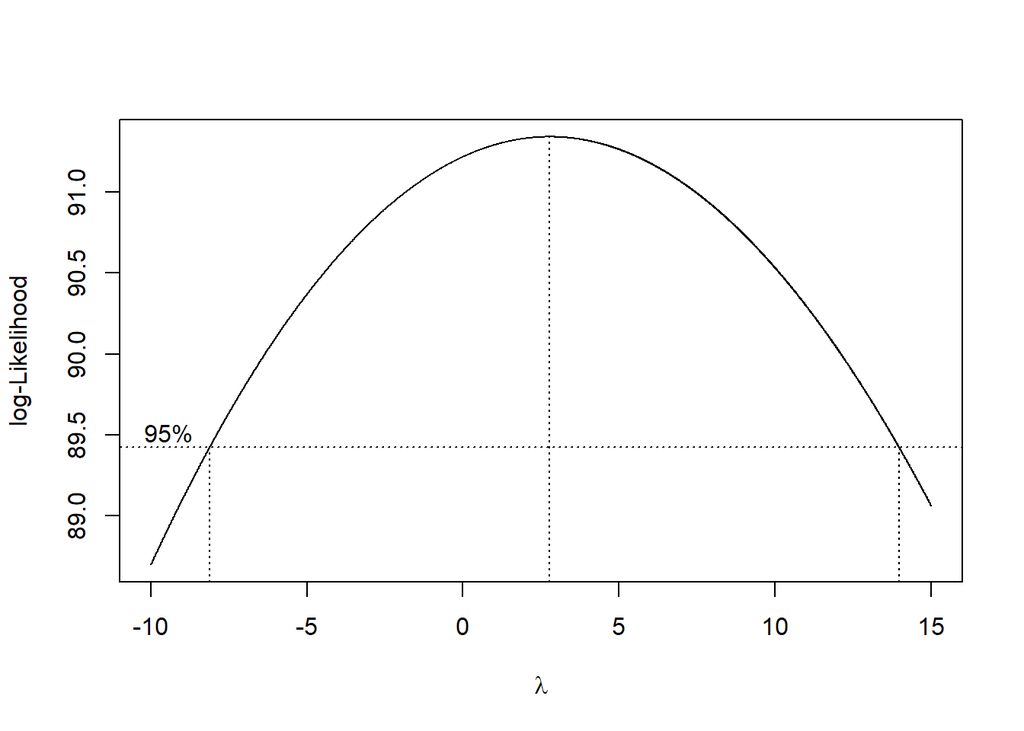

```r
index <- seq(1:52)
bc = boxcox(dt_stas1~index, lambda = seq(-10,15,by=0.01))
```

```r
#Nilai Rounded Lambda
lambda <- bc$x[which.max(bc$y)]
lambda
```

```
## [1] 2.77
```

```r
#SK
bc$x[bc$y > max(bc$y) - 1/2 * qchisq(.95,1)]
```

```
##    [1] -8.12 -8.11 -8.10 -8.09 -8.08 -8.07 -8.06 -8.05 -8.04 -8.03 -8.02 -8.01
##   [13] -8.00 -7.99 -7.98 -7.97 -7.96 -7.95 -7.94 -7.93 -7.92 -7.91 -7.90 -7.89
##   [25] -7.88 -7.87 -7.86 -7.85 -7.84 -7.83 -7.82 -7.81 -7.80 -7.79 -7.78 -7.77
##   [37] -7.76 -7.75 -7.74 -7.73 -7.72 -7.71 -7.70 -7.69 -7.68 -7.67 -7.66 -7.65
##   [49] -7.64 -7.63 -7.62 -7.61 -7.60 -7.59 -7.58 -7.57 -7.56 -7.55 -7.54 -7.53
##   [61] -7.52 -7.51 -7.50 -7.49 -7.48 -7.47 -7.46 -7.45 -7.44 -7.43 -7.42 -7.41
##   [73] -7.40 -7.39 -7.38 -7.37 -7.36 -7.35 -7.34 -7.33 -7.32 -7.31 -7.30 -7.29
##   [85] -7.28 -7.27 -7.26 -7.25 -7.24 -7.23 -7.22 -7.21 -7.20 -7.19 -7.18 -7.17
##   [97] -7.16 -7.15 -7.14 -7.13 -7.12 -7.11 -7.10 -7.09 -7.08 -7.07 -7.06 -7.05
##  [109] -7.04 -7.03 -7.02 -7.01 -7.00 -6.99 -6.98 -6.97 -6.96 -6.95 -6.94 -6.93
##  [121] -6.92 -6.91 -6.90 -6.89 -6.88 -6.87 -6.86 -6.85 -6.84 -6.83 -6.82 -6.81
##  [133] -6.80 -6.79 -6.78 -6.77 -6.76 -6.75 -6.74 -6.73 -6.72 -6.71 -6.70 -6.69
##  [145] -6.68 -6.67 -6.66 -6.65 -6.64 -6.63 -6.62 -6.61 -6.60 -6.59 -6.58 -6.57
##  [157] -6.56 -6.55 -6.54 -6.53 -6.52 -6.51 -6.50 -6.49 -6.48 -6.47 -6.46 -6.45
##  [169] -6.44 -6.43 -6.42 -6.41 -6.40 -6.39 -6.38 -6.37 -6.36 -6.35 -6.34 -6.33
```

[output cut: 170 more lines]

Gambar di atas menunjukkan nilai rounded value ($\lambda$) optimum sebesar 2.77 dan pada selang kepercayaan 95% nilai memiliki batas bawah -8.12 dan batas atas 13.97. Selang tersebut memuat nilai satu sehingga dapat dikatakan bahwa data suhu **stasioner dalam ragam**.

## Bagian 2 (Data 1 - 104)

```r
dt_stas2 <- data1.ts[1:104] |> ts()
mean(dt_stas2)
```

```
## [1] 24.10462
```

```r
var(dt_stas2)
```

```
## [1] 0.3937202
```

## Plot *Time Series*

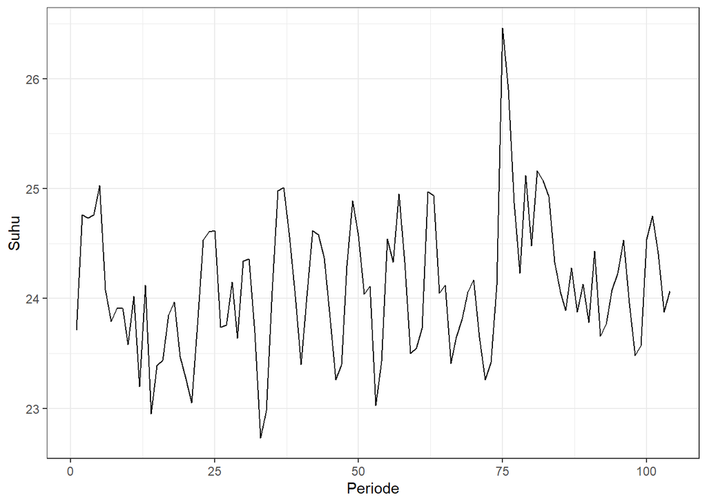

```r
dt_stas2 |> as_tsibble() |>
  ggplot(aes(x = index, y = value)) +
  geom_line() + theme_bw() +
  xlab("Periode") + ylab("Suhu")
```

Plot deret waktu di atas menunjukkan bahwa data stasioner dalam rataan, ditandai dengan data yang menyebar di sekitar nilai tengahnya (24) dan namun ada lebar pita yang tidak sama sehingga ada kemungkinan bahwa data tidak stasioner dalam ragam.

## Plot ACF

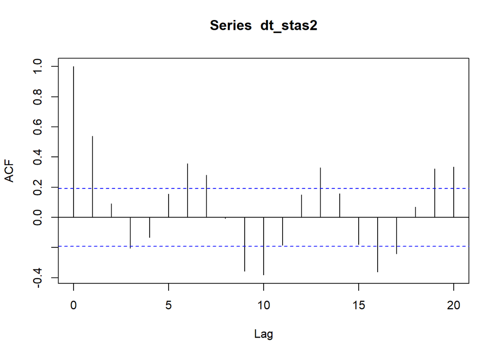

```r
acf(dt_stas2)
```

Berdasarkan plot ACF, terlihat bahwa plot ACF pada data tersebut cenderung *tails off* dan membentuk gelombang sinus.

## Uji ADF

```r
tseries::adf.test(dt_stas2)
```

```
##
##  Augmented Dickey-Fuller Test
##
## data:  dt_stas2
## Dickey-Fuller = -3.8381, Lag order = 4, p-value = 0.01973
## alternative hypothesis: stationary
```

$H_0$ : Data tidak stasioner dalam rataan

$H_1$ : Data stasioner dalam rataan

Berdasarkan uji ADF tersebut, didapat p-value sebesar 0.01973 yang lebih kecil dari taraf nyata 5% sehingga tolak $H_0$ dan menandakan bahwa data **stasioner dalam rataan**. Hal ini sesuai dengan hasil eksplorasi menggunakan plot time series dan plot ACF.

## Plot Boxcox

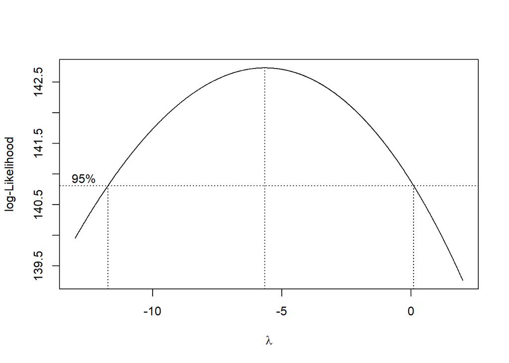

```r
index <- seq(1:104)
bc = boxcox(dt_stas2~index, lambda = seq(-13,2,by=0.01))
```

```r
#Nilai Rounded Lambda
lambda <- bc$x[which.max(bc$y)]
lambda
```

```
## [1] -5.66
```

```r
#SK
bc$x[bc$y > max(bc$y) - 1/2 * qchisq(.95,1)]
```

```
##    [1] -11.72 -11.71 -11.70 -11.69 -11.68 -11.67 -11.66 -11.65 -11.64 -11.63
##   [11] -11.62 -11.61 -11.60 -11.59 -11.58 -11.57 -11.56 -11.55 -11.54 -11.53
##   [21] -11.52 -11.51 -11.50 -11.49 -11.48 -11.47 -11.46 -11.45 -11.44 -11.43
##   [31] -11.42 -11.41 -11.40 -11.39 -11.38 -11.37 -11.36 -11.35 -11.34 -11.33
##   [41] -11.32 -11.31 -11.30 -11.29 -11.28 -11.27 -11.26 -11.25 -11.24 -11.23
##   [51] -11.22 -11.21 -11.20 -11.19 -11.18 -11.17 -11.16 -11.15 -11.14 -11.13
##   [61] -11.12 -11.11 -11.10 -11.09 -11.08 -11.07 -11.06 -11.05 -11.04 -11.03
##   [71] -11.02 -11.01 -11.00 -10.99 -10.98 -10.97 -10.96 -10.95 -10.94 -10.93
##   [81] -10.92 -10.91 -10.90 -10.89 -10.88 -10.87 -10.86 -10.85 -10.84 -10.83
##   [91] -10.82 -10.81 -10.80 -10.79 -10.78 -10.77 -10.76 -10.75 -10.74 -10.73
##  [101] -10.72 -10.71 -10.70 -10.69 -10.68 -10.67 -10.66 -10.65 -10.64 -10.63
##  [111] -10.62 -10.61 -10.60 -10.59 -10.58 -10.57 -10.56 -10.55 -10.54 -10.53
##  [121] -10.52 -10.51 -10.50 -10.49 -10.48 -10.47 -10.46 -10.45 -10.44 -10.43
##  [131] -10.42 -10.41 -10.40 -10.39 -10.38 -10.37 -10.36 -10.35 -10.34 -10.33
##  [141] -10.32 -10.31 -10.30 -10.29 -10.28 -10.27 -10.26 -10.25 -10.24 -10.23
```

[output cut: 104 more lines]

Gambar di atas menunjukkan nilai rounded value ($\lambda$) optimum sebesar -5.66 dan pada selang kepercayaan 95% nilai memiliki batas bawah -11.72 dan batas atas 0.09. Selang tersebut tidak memuat nilai satu sehingga dapat dikatakan bahwa data suhu **tidak stasioner dalam ragam**.